# m30_ive_index

```python
import numpy as np
import pandas as pd
import scipy.stats as sp_stats
import time
import yfinance as yf
import matplotlib.pyplot as plt
import matplotlib.dates as mdates
import os

import warnings
warnings.filterwarnings('ignore')
```

## **Module 1: Data Acquisition**

This module is responsible for sourcing and cleaning the raw price data that feeds every downstream calculation in the MQ30 pipeline.

### What it does

**`get_sp500_tickers()`**

Scrapes the current S&P 500 constituent list from Wikipedia and returns ticker symbols as a Python list. Dots are converted to dashes (`BRK.B` -> `BRK-B`) to match the yfinance convention. Falls back to a hardcoded 50-stock subset if the Wikipedia request fails.

**`download_prices(tickers, start, end)`**

Calls `yfinance.download()` in bulk to fetch **split- and dividend-adjusted** daily closing prices (`auto_adjust=True`) for every ticker over the requested date range. A one-year look-back window before `START_DATE` is included so that momentum and volatility signals are available from the very first rebalance. Raises a `RuntimeError` if yfinance returns no usable data rather than silently continuing on bad inputs.

**`clean_prices(df)`**

Applies two cleaning steps to the raw price matrix:

1. **Forward-fill**: Propagates the last valid price across gaps of up to 5 consecutive trading days (handles holidays, halts, and thin markets).
2. **Column drop**: Removes any ticker whose price history is still more than 20 % missing after forward-filling (e.g. recent IPOs or delisted names that joined the index mid-period).

### Output:

A `pd.DataFrame` with shape `(trading_days × tickers)`, a `DatetimeIndex`, and no leading/trailing all-NaN rows, ready to be consumed by the selection and index-engine modules.

### Design notes

- Using `auto_adjust=True` means all prices are back-adjusted for corporate actions, so Module 5's split simulation starts from a clean, unadjusted baseline for demonstration purposes.
- The 5-day forward-fill limit is intentionally conservative; a longer fill would mask genuine data outages and distort volatility estimates.
- Tickers with > 20 % missing data are dropped rather than imputed, since momentum and volatility signals computed on heavily imputed series are unreliable.

```python
# Web-scrape Wikipedia for list of all tickers in the S&P500
def get_sp500_tickers():
    """
    Returns all S&P500 from a Wikipedia page.
    Fall back to a hardcoded subset.
    """
    try:
        table = pd.read_html('https://en.wikipedia.org/wiki/List_of_S%26P_500_companies', header=0)[0]
        tickers = table['Symbol'].str.replace('.', '-', regex=False).tolist()
        print(f'Fetched{len(tickers)} from Wikipedia.')
        return tickers
    except Exception as e:
        print(f'Wikipedia fetch failed({e}); using fallback list.')
        tickers = [
            'AAPL','MSFT','GOOGL','AMZN','NVDA','META','TSLA','BRK-B','UNH','JNJ',
            'JPM','V','PG','XOM','HD','CVX','MA','LLY','ABBV','MRK',
            'AVGO','PEP','KO','COST','TMO','WMT','MCD','ACN','CSCO','ABT',
            'BAC','DHR','LIN','TXN','AMGN','NEE','PM','RTX','HON','QCOM',
            'UPS','IBM','SBUX','GILD','CAT','GS','BLK','MDLZ','AXP','INTU'
        ]
        return tickers

# Download close price data
def download_prices(tickers, start, end):
    """
    Downloads split/dividend-adjusted daily close prices for all tickers via yfinance.
    Raises error if the download returns no usable data.
    """
    print(f'Downlaoding {len(tickers)} ticker data.')
    print(f'Start Date: {start}')
    print(f'End Date: {end}')

    raw = yf.download(tickers, start=start, end=end, auto_adjust=True,
                            progress=False, threads=True)['Close']

    if isinstance(raw, pd.Series):      # Single ticker edge classmethod
        raw=raw.to_frame(tickers[0])

    n_valid = int(raw.notna().any().sum())
    coverage = raw.notna().mean()
    print(f'{n_valid}/{len(tickers)} tickers returned data.')

    if n_valid == 0:
        raise RuntimeError('[Flag] yfinance returned no data.')

    return raw

# Cleaning the dataset
def clean_prices(df, max_gap=5, max_missing_pct=0.20):
    """
    1. Sort chronologically.
    2. Forward-fill any gaps upto (max_gap) consecutive days.
    3. Drop tickers with > max_missing_pct NaN.
    """

    df = df.sort_index().ffill(limit=max_gap)
    missing_frac = df.isna().mean()
    kept = missing_frac[missing_frac <= max_missing_pct].index
    dropped = len(df.columns) - len(kept)
    if dropped:
        print(f'Dropped {dropped} tickers with > {max_missing_pct:.0%} missing data.')
    return df[kept].dropna(how='all')
```

## **Module 2: Selection & Weighting**

This module answers two questions at every quarterly rebalance: **which 30 stocks enter the index, and how much weight does each get?**

### **What it does**

**`compute_momentum_clenow(prices, as_of)`** An alternative momentum score based on Andreas Clenow's methodology. Fits an OLS regression of `ln(price)` on time over the trailing 90 days. Toggle between the two with `USE_CLENOW`.

**`compute_realized_vol(prices, as_of)`** Annualised 60-day realised volatility, computed as the standard deviation of daily log annualized. Used both for the volatility filter and for inverse-vol weighting.

**`select_constituents(prices, as_of, n=30)`** Runs the full selection pipeline in four steps:

1. Score every ticker in the cleaned universe by momentum.
2. **Volatility filter**: Remove the top decile (90th percentile) by 60-day realised vol.
3. **Rank and select**: Take the top 30 by momentum score from the filtered universe.
4. **Inverse-volatility weighting**: Assign weights proportional to 1/$\sigma_i$, normalised to sum to 1. Lower-volatility constituents receive larger weights, dampening overall portfolio risk without any optimisation solver.

### **Output**

A `pd.DataFrame` with index `ticker` and columns `weight`, `momentum`, and `volatility`, one row per selected constituent.

### **Design notes**

```python
def compute_momentum_simple(prices, as_of, lookback_days=252):
    """
    12-month total return ending 1 month before as_of.
    Skipping the lsat month avoids short-term reversal effects.
    """
    end_idx = prices.index.get_indexer([as_of], method='ffill')[0]
    skip = 21
    start_idx = end_idx - lookback_days
    if start_idx < 0:
        return pd.Series(dtype=float)
    return ((prices.iloc[end_idx - skip] / prices.iloc[start_idx]) - 1.0).dropna()

def compute_momentum_clenow(prices, as_of, lookback_days=90):
    """
    Clenow momentum: OLS of ln(price) on time over trailing 90 days.
    Score = ((1 + annualised_slope)^252) * R^2
    Rewards both trend strength (slope) and consistency.
    """
    end_idx = prices.index.get_indexer([as_of], method='ffill')[0]
    start_idx = end_idx - lookback_days + 1
    if start_idx < 0:
        return pd.Series(dtype=float)
    window = prices.iloc[start_idx: end_idx + 1]
    t = np.arange(len(window))
    scores = {}
    for col in window.columns:
        y = np.log(window[col].dropna())
        if len(y) < lookback_days * 0.8:
            continue
        t_aligned = t[window[col].notna()]          # was missing entirely
        slope, _, r, _, _ = sp_stats.linregress(t_aligned, y)
        scores[col] = ((1 + slope) ** 252) * (r ** 2)
    return pd.Series(scores).dropna()

def compute_realized_vol(prices, as_of, window=60):
    """
    Annualized 60-day rolling volatility from daily log returns.
    """
    end_idx = prices.index.get_indexer([as_of], method='ffill')[0]
    start_idx = max(end_idx - window, 0)
    rets = np.log(prices.iloc[start_idx: end_idx + 1]).diff().dropna()
    return (rets.std() * np.sqrt(252)).dropna()
```

```python
def select_constituents(prices, as_of, n=30, use_clenow=False, vol_filter_quantile=0.90):
    """
    Select top-n constituents as of the as_of date.

    Steps:
        1. Score all tickers by momentum.
        2. Remove top decile of by 60-day vol(cuts out high momentum blow-up names).
        3. Pick top-n from the remaining universe.
        4. Weight by inverse-volatility.

    Returns: DataFrame(index=ticker, columns=[weight, momentum, volatility])
    """

    mom = compute_momentum_clenow(prices, as_of) if use_clenow \
          else compute_momentum_simple(prices, as_of)
    vol = compute_realized_vol(prices, as_of)

    common = mom.index.intersection(vol.index)      # was comma, not dot
    mom, vol = mom[common], vol[common]

    vol_cap  = vol.quantile(vol_filter_quantile)
    eligible = vol[vol <= vol_cap].index
    top_n    = mom[eligible].sort_values(ascending=False).head(n).index.tolist()

    sel_vol  = vol[top_n]
    inv_vol  = 1.0 / sel_vol
    weights  = (inv_vol / inv_vol.sum()).rename('weight')  # parens were wrong

    return pd.DataFrame({
        'weight':     weights,
        'momentum':   mom[top_n],
        'volatility': sel_vol,
    })
```

## **Module 3: Index Engine**

This module is the core of the MQ30 pipeline. It takes the cleaned price data and the selection logic from Module 2 and produces a continuous daily index level series using the **Laspeyres chain-linked divisor methodology**.

### **Core Formula**

$Index Level_t = \frac{\sum (Price_{i,t} \times Notional Units_i)}{Divisor}$

**`Notional_Units_i`** are fixed between rebalances, only prices move, so the index purely reflects market price changes in the held basket.

### **What it does**

**`get_rebalance_dates(trading_days)`**

Identifies the **last trading day of March, June, September, and December** for every year in the data range. These are the MQ30 quarterly rebalance dates, consistent with how most institutional equity indices schedule turnover.

**`compute_portfolio_value(prices_row, notional)`**

Computes $\sum(Price_{i} \times Notional_{i})$ for a single day. Tickers with a missing price on that day are skipped rather than treated as zero, so isolated data gaps do not distort the index level.

**`run_index(prices, start_date, end_date)`**

Runs the full daily index calculation in three phases:

#### **Phase 1: Initialisation (first rebalance date)**

Selects the initial 30 constituents, computes inverse-vol weights, and converts dollar weights into notional share units:

$Notional_{i} = \frac{weight_{i} \times PortfolioValue}{Price_{i}}$

The opening divisor is set so the index starts exactly at 1000:

$Divisor_{0} = \frac {Portfolio Value_{0}}{1000}$

#### **Phase 2: Daily mark-to-market**

On every trading day the index level is simply:

$Level_{t} = \frac {\sum(Price_{i, t} \times Notional_{i})}{Divisor}$

Notional units and the divisor are both held constant between rebalances, so any change in the index level reflects only price movement.

#### **Phase 3: Rebalance & divisor adjustment**

On each subsequent quarterly rebalance date, a new constituent basket is selected and new notional units are computed. The divisor is then adjusted to ensure the index level does not jump:

$New Divisor = \frac {New Portfolio Value}{Pre-rebalance Index Level}$

This is the chain-linking step, it absorbs the mechanical effect of turnover and reweighting so the index remains a pure measure of price return from inception.

### **Outputs**

| Output | Type | Description |
| --- | --- | --- |
| `index_levels` | `pd.Series` | Daily MQ30 index level, base 1000 |
| `rebalance_log` | `pd.DataFrame` | Divisor, portfolio values, and constituent count at each rebalance |
| `constituent_history` | `pd.DataFrame` | Ticker, weight, momentum, volatility, notional units at every rebalance |

### **Design notes**

- The divisor is the only state that carries forward across rebalances, everything else (notional units, weights) is recomputed fresh each quarter.
- Skipping price gaps with `prices_row.get(t, np.nan)` rather than raising means a single bad data point never halts the entire index run.
- The `initial_portfolio_value` parameter (default $1M) is arbitrary, it scales notional units but cancels out in the divisor ratio, so the index level is independent of it.

```python
BASE_LEVEL = 1000.0


def get_rebalance_dates(trading_days):
    rebalance = []                                  # was 'rebalnce'
    for year in range(trading_days.year.min(), trading_days.year.max() + 1):
        for month in (3, 6, 9, 12):
            month_days = trading_days[
                (trading_days.year == year) & (trading_days.month == month)
            ]
            if len(month_days):
                rebalance.append(month_days[-1])
    return sorted(rebalance)                        # was sort() — not a builtin


def compute_portfolio_value(prices_row, notional):
    return sum(
        prices_row.get(t, np.nan) * u
        for t, u in notional.items()
        if not np.isnan(prices_row.get(t, np.nan))
    )


def run_index(prices, start_date, end_date,
              use_clenow=False,                     # was use_cleanow
              n_constituents=30,
              initial_portfolio_value=1_000_000.0):

    trading_days    = prices.loc[start_date:end_date].index
    rebalance_dates = get_rebalance_dates(trading_days)

    first_reb = next(
        (d for d in rebalance_dates if d >= pd.Timestamp(start_date)), None   # Timestamp, and None outside generator
    )
    if first_reb is None:
        raise ValueError('No rebalance date found in range.')

    # Phase 1: Initialisation
    constituents_df = select_constituents(
        prices, first_reb, n=n_constituents, use_clenow=use_clenow
    )
    init_prices = prices.loc[first_reb, constituents_df.index]
    weights     = constituents_df['weight']
    notional    = {
        t: (weights[t] * initial_portfolio_value) / init_prices[t]
        for t in constituents_df.index
    }
    divisor = compute_portfolio_value(prices.loc[first_reb], notional) / BASE_LEVEL

    # Phase 2 & 3: Daily loop
    active_days   = list(trading_days[trading_days >= first_reb])
    rebalance_set = set(rebalance_dates)
    index_levels, reb_rows, hist_rows = {}, [], []

    for i, day in enumerate(active_days):
        row = prices.loc[day]

        if day in rebalance_set and day != first_reb:
            pre_level = index_levels[active_days[i - 1]]
            new_c     = select_constituents(
                prices, day, n=n_constituents, use_clenow=use_clenow
            )
            old_pv       = compute_portfolio_value(row, notional)
            new_notional = {
                t: (new_c.loc[t, 'weight'] * old_pv) / prices.loc[day, t]
                for t in new_c.index
            }
            new_pv  = compute_portfolio_value(row, new_notional)
            divisor = new_pv / pre_level

            reb_rows.append({
                'date': day, 'pre_index_level': pre_level,
                'old_portfolio_value': old_pv, 'new_portfolio_value': new_pv,
                'divisor': divisor, 'n_constituents': len(new_notional),
            })
            notional        = new_notional
            constituents_df = new_c

        level = compute_portfolio_value(row, notional) / divisor
        index_levels[day] = level

        if day in rebalance_set:
            for ticker in notional:
                in_c = ticker in constituents_df.index
                hist_rows.append({
                    'date': day, 'ticker': ticker,
                    'weight':         constituents_df.loc[ticker, 'weight']     if in_c else np.nan,
                    'momentum':       constituents_df.loc[ticker, 'momentum']   if in_c else np.nan,
                    'volatility':     constituents_df.loc[ticker, 'volatility'] if in_c else np.nan,
                    'notional_units': notional[ticker],
                    'price':          row.get(ticker, np.nan),
                })

    index_series = pd.Series(index_levels, name='MQ30')
    reb_log = pd.DataFrame(reb_rows).set_index('date') if reb_rows else pd.DataFrame()
    hist    = pd.DataFrame(hist_rows) if hist_rows else pd.DataFrame()
    return index_series, reb_log, hist, notional, divisor
```

## **Module 4: Data Quality**

Before trusting any index output, the pipeline must verify that the underlying price data and the computed index levels are free of errors that would silently corrupt results. This module runs four independent checks and consolidates them into a single quality report.

### **What it does**

**`check_stale_prices(prices, threshold=3)`**

Detects tickers whose price has not changed for 3 or more consecutive trading days. A genuine price rarely stays perfectly flat for that long, this pattern almost always indicates a data feed outage, a halted stock that was not removed, or a vendor filling missing values by repeating the last known price. Flags every affected ticker-date pair.

**`check_missing_data(prices)`**

Reports the fraction of trading days with no price for each ticker after cleaning. Even after forward-filling, some tickers may have structural gaps (recent IPOs, short listing histories). This check makes those gaps visible rather than letting them silently reduce the investable universe.

**`check_return_outliers(prices, threshold=0.15)`**

Flags any daily log-return whose absolute value exceeds 15%. Moves of this size are rare for large-cap equities outside of genuine corporate events (mergers, earnings surprises). When they appear in clean data they most often signal a price adjustment error, a dividend that was not stripped, or a bad tick from the data vendor.

**`check_index_anomalies(index_levels, threshold=0.05)`**

Flags days where the MQ30 index itself moves more than ±5% in a single session. Unlike individual stock outliers, an index-level anomaly indicates a systemic problem, a divisor calculation error, a bulk bad price affecting multiple constituents, or a rebalance that did not execute cleanly.

**`run_quality_checks(prices, index_levels)`**

Runs all four checks and concatenates the results into a single `pd.DataFrame` with a `severity` column:

| Severity | Checks |
| --- | --- |
| `info` | Missing data (expected for some tickers) |
| `warning` | Stale prices, return outliers |
| `critical` | Index-level anomalies |

### **Output**

A combined `pd.DataFrame` saved to `quality_report.csv`. An empty DataFrame means the data passed all checks cleanly.

### **Design notes**

- Checks are intentionally independent, a single bad ticker can trigger stale, missing, and outlier flags simultaneously, all of which are useful for diagnosis.
- Thresholds (3-day stale, 15% return, 5% index move) are conservative by design. False positives are preferable to missed errors in a production index context.

```python
def check_stale_prices(prices, threshold=3):
    """Flag tickers with >= threshold consecutive unchanged prices."""
    flags = []
    for col in prices.columns:
        s = prices[col].dropna()
        streak = (s != s.shift(1)).cumsum()
        run_lengths = streak.map(streak.value_counts())
        for dt in run_lengths[run_lengths >= threshold].index:
            flags.append({'ticker': col, 'date': dt,
                          'price': s[dt], 'check': 'stale_price'})
    return pd.DataFrame(flags)


def check_missing_data(prices):
    """Report missing-data percentage per ticker."""
    m = prices.isna().mean().rename('missing_pct')
    m = m[m > 0].reset_index()
    m.columns = ['ticker', 'missing_pct']
    m['check'] = 'missing_data'
    return m


def check_return_outliers(prices, threshold=0.15):
    """Flag |daily log-return| > threshold (default 15%)."""
    lr = np.log(prices / prices.shift(1))
    rows = []
    for col in lr.columns:
        bad = lr[col][lr[col].abs() > threshold].dropna()
        for dt, val in bad.items():
            rows.append({'ticker': col, 'date': dt,
                         'log_return': val, 'check': 'return_outlier'})
    return pd.DataFrame(rows)


def check_index_anomalies(index_levels, threshold=0.05):
    """Flag index daily moves > ±threshold (default 5%)."""
    flags = index_levels.pct_change()
    flags = flags[flags.abs() > threshold].dropna()
    return pd.DataFrame([{
        'date':         dt,
        'index_return': v,
        'index_level':  index_levels[dt],
        'check':        'index_anomaly',
    } for dt, v in flags.items()])


def run_quality_checks(prices, index_levels):
    """Run all four checks; return combined quality report DataFrame."""
    parts = []
    checks = [
        (check_stale_prices(prices),         'warning',  'stale_price'),
        (check_missing_data(prices),          'info',     'missing_data'),
        (check_return_outliers(prices),       'warning',  'return_outlier'),
        (check_index_anomalies(index_levels), 'critical', 'index_anomaly'),
    ]
    for df, severity, label in checks:
        print(f'  {label:<22}: {len(df)} flags')
        if len(df):
            parts.append(df.assign(severity=severity))

    return (pd.concat(parts, ignore_index=True, sort=False)
            if parts
            else pd.DataFrame(columns=['ticker', 'date', 'check', 'severity']))
```

## **Test simulation**

```
Downlaoding 40 ticker data.
Start Date: 2019-01-01
End Date: 2022-12-31
40/40 tickers returned data.
Price matrix: 1008 days * 40 tickers
Date range  : 2019-01-02 - 2022-12-30
Constituents selected as of 2021-03-31: 30
Weight sum (should be 1.0): 1.000000

Top 10 by weight:
       weight momentum volatility
Ticker
JNJ     4.80%   24.55%     17.68%
MCD     4.58%   29.33%     18.53%
KO      4.50%   16.08%     18.89%
COST    4.25%   19.20%     19.97%
HON     4.23%   57.85%     20.09%
UNH     4.02%   35.81%     21.12%
CSCO    3.94%   19.87%     21.58%
WMT     3.90%   15.91%     21.78%
UPS     3.83%   77.85%     22.21%
HD      3.69%   41.75%     23.04%


Index Engine
Index days computed : 695
Rebalances executed : 11
Start level         : 1000.0000  (should be 1000.0)
End level           : 1884.9402
Total return        : 88.49%

Rebalance log:
            pre_index_level      divisor  n_constituents
date
2020-06-30      1171.149408  1016.135714              30
2020-09-30      1293.904796  1026.979124              30
2020-12-31      1410.233337  1037.753027              30
2021-03-31      1453.406138  1042.002493              30
2021-06-30      1564.146128  1044.812534              30
2021-09-30      1593.400826  1031.670150              30
```

[output cut: 25 more lines]

```

Total flags: 40

Sample flags:
ticker       date  price          check severity  log_return  index_return  index_level
   NaN 2020-06-11    NaN  index_anomaly critical         NaN     -0.050891  1150.144171
   NaN 2020-04-06    NaN  index_anomaly critical         NaN      0.061453  1041.629243
  SBUX 2020-03-16    NaN return_outlier  warning   -0.176788           NaN          NaN
  INTU 2020-03-24    NaN return_outlier  warning    0.182989           NaN          NaN
   JPM 2020-03-13    NaN return_outlier  warning    0.165620           NaN          NaN
   JPM 2020-03-16    NaN return_outlier  warning   -0.162106           NaN          NaN
    MA 2020-03-24    NaN return_outlier  warning    0.153673           NaN          NaN
   MCD 2020-03-16    NaN return_outlier  warning   -0.172870           NaN          NaN
   MCD 2020-03-24    NaN return_outlier  warning    0.166577           NaN          NaN
  META 2020-03-16    NaN return_outlier  warning   -0.153769           NaN          NaN
```

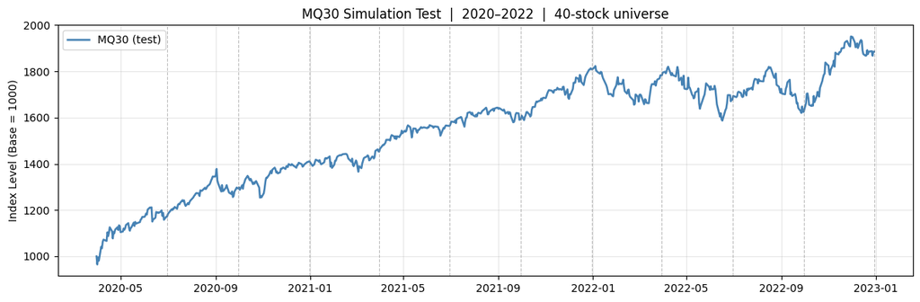

```python
TEST_TICKERS = [
    'AAPL','MSFT','GOOGL','AMZN','NVDA','META','JPM','V','UNH','JNJ',
    'PG','XOM','HD','CVX','MA','LLY','ABBV','MRK','KO','PEP',
    'COST','WMT','MCD','CSCO','ABT','BAC','TXN','AMGN','NEE','IBM',
    'SBUX','GILD','CAT','GS','BLK','AXP','INTU','HON','QCOM','UPS'
]

TEST_START = '2020-01-01'
TEST_END   = '2022-12-31'

# Data
lookback_start = str(int(TEST_START[:4]) - 1) + TEST_START[4:]
raw = download_prices(TEST_TICKERS, start=lookback_start, end=TEST_END)
prices_test = clean_prices(raw)
print(f'Price matrix: {prices_test.shape[0]} days * {prices_test.shape[1]} tickers')
print(f'Date range  : {prices_test.index[0].date()} - {prices_test.index[-1].date()}')

# Spot-check selection at one rebalance date
test_date = pd.Timestamp('2021-03-31')
c = select_constituents(prices_test, as_of=test_date, n=30)
print(f'Constituents selected as of {test_date.date()}: {len(c)}')
print(f'Weight sum (should be 1.0): {c["weight"].sum():.6f}')
print(f'\nTop 10 by weight:')
top10 = c.sort_values('weight', ascending=False).head(10).copy()
top10['weight']     = top10['weight'].map('{:.2%}'.format)
top10['momentum']   = top10['momentum'].map('{:.2%}'.format)
top10['volatility'] = top10['volatility'].map('{:.2%}'.format)
print(top10.to_string())

# Run index engine
print('\n')
print('Index Engine')

index_test, reb_log_test, hist_test, final_notional, final_divisor = run_index(
    prices_test,
    start_date=TEST_START,
    end_date=TEST_END,
    n_constituents=30,
    use_clenow=False,
)

print(f'Index days computed : {len(index_test)}')
print(f'Rebalances executed : {len(reb_log_test)}')
print(f'Start level         : {index_test.iloc[0]:.4f}  (should be 1000.0)')
print(f'End level           : {index_test.iloc[-1]:.4f}')
print(f'Total return        : {(index_test.iloc[-1]/index_test.iloc[0] - 1):.2%}')

print('\nRebalance log:')
print(reb_log_test[['pre_index_level','divisor','n_constituents']].to_string())

# Continuity check(index should never jump at a rebalance date)
print('\nContinuity check at each rebalance:')
for reb_date in reb_log_test.index:
    loc = list(index_test.index).index(reb_date)
    before = index_test.iloc[loc - 1]
    after  = index_test.iloc[loc]
    delta  = abs(after - before) / before
    status = 'OK' if delta < 0.10 else 'WARN'  # rebalance day can move with market
    print(f'  {reb_date.date()}  before={before:.2f}  after={after:.2f}  diff={delta:.4%}  [{status}]')

# Quality checks
print('\n')
print('Data Quality')
qr = run_quality_checks(prices_test, index_test)
print(f'\nTotal flags: {len(qr)}')
if len(qr):
    print('\nSample flags:')
    print(qr.sort_values('severity').head(10).to_string(index=False))

# Plot
fig, ax = plt.subplots(figsize=(12, 4))
ax.plot(index_test.index, index_test.values, lw=1.8, color='steelblue', label='MQ30 (test)')
for d in reb_log_test.index:
    ax.axvline(d, color='grey', lw=0.8, ls='--', alpha=0.5)
ax.set_title('MQ30 Simulation Test  |  2020–2022  |  40-stock universe', fontsize=12)
ax.set_ylabel('Index Level (Base = 1000)')
ax.xaxis.set_major_formatter(mdates.DateFormatter('%Y-%m'))
ax.legend()
ax.grid(alpha=0.3)
plt.tight_layout()
plt.show()
```

## **Module 5: Corporate Action Simulation**

A production index must handle corporate actions like splits, spin-offs, rights issues without introducing artificial jumps in the index level. This module simulates a **2:1 stock split** on a single constituent and verifies that the index remains continuous across the event.

### **Why splits matter for an index?**

When a stock splits 2:1, its price halves but the number of shares doubles. If the index held raw share counts and did nothing, the portfolio value would appear to drop by half for that constituent, a ghost loss that has nothing to do with actual market returns. The fix is to simultaneously adjust both the price series and the notional units so that `Price * Units` is unchanged on ex-date.

### **What it does**

**`apply_stock_split(prices, notional, ticker, ex_date, ratio=2.0)`**

Because `Price × Units` is unchanged, the portfolio value and thereforethe index level are unaffected. The divisor does **not** change.

**`simulate_corp_action(prices, index_levels, notional, divisor)`**

Orchestrates the full simulation end-to-end:

1. Picks the first constituent and applies a 2:1 split at the midpoint of the index history.
2. Calls `verify_index_continuity` and prints a human-readable report.
3. Returns the full results dict for inspection.

### **Design notes**

- Back-adjusting historical prices rather than only adjusting forward keeps the entire price series on a consistent scale, essential for momentum and volatility calculations that look back through the split.
- The divisor is deliberately left unchanged to demonstrate that a pure bookkeeping split requires no divisor intervention, only a rebalance or a constituent change does.
- In a real production system this logic would be triggered automatically by a corporate action feed (e.g. from ICE, Refinitiv, or Bloomberg) on the evening before ex-date.

```python
def apply_stock_split(prices, notional, ticker, ex_date, ratio=2.0):
    """
    Simulate a ratio:1 split on ticker.
    Divides the ENTIRE price series by ratio (back-adjusts history and
    simulates the ex-date price drop). Doubles notional units.
    Net result: price × units is identical on every day.
    """
    if ticker not in prices.columns:
        raise ValueError(f'{ticker} not found in price data.')
    if ticker not in notional:
        raise ValueError(f'{ticker} not found in notional units.')

    adj_prices = prices.copy()
    adj_prices[ticker] = adj_prices[ticker] / ratio   # full-series adjustment
    adj_notional = {**notional, ticker: notional[ticker] * ratio}

    return adj_prices, adj_notional


def verify_index_continuity(orig_prices_on_exdate, adj_prices_on_exdate,
                             notional_before, notional_after, tol=1e-8):
    """
    pv_before = original prices × original units  (pre-split)
    pv_after  = adjusted prices × adjusted units  (post-split)
    These must be equal — split is pure bookkeeping.
    """
    pv_before = sum(
        orig_prices_on_exdate.get(t, np.nan) * u
        for t, u in notional_before.items()
        if not np.isnan(orig_prices_on_exdate.get(t, np.nan))
    )
    pv_after = sum(
        adj_prices_on_exdate.get(t, np.nan) * u
        for t, u in notional_after.items()
        if not np.isnan(adj_prices_on_exdate.get(t, np.nan))
    )
    diff = abs(pv_after - pv_before)
    return {
        'portfolio_value_before': pv_before,
        'portfolio_value_after':  pv_after,
        'absolute_difference':    diff,
        'relative_difference':    diff / pv_before if pv_before else 0,
        'continuity_maintained':  diff < tol * pv_before,
    }


def simulate_corp_action(prices, index_levels, notional, divisor=None,
                          ticker=None, ratio=2.0):
    if ticker is None:
        ticker = list(notional.keys())[0]

    mid     = len(index_levels) // 2
    ex_date = index_levels.index[mid]

    adj_prices, adj_notional = apply_stock_split(
        prices, notional, ticker, ex_date, ratio
    )

    result = verify_index_continuity(
        prices.loc[ex_date],        # original prices to pv_before
        adj_prices.loc[ex_date],    # halved split-ticker price to pv_after
        notional,
        adj_notional,
    )

    result.update({
        'ticker':       ticker,
        'ex_date':      ex_date,
        'split_ratio':  ratio,
        'units_before': notional[ticker],
        'units_after':  adj_notional[ticker],
        'price_before': prices.loc[ex_date, ticker],
        'price_after':  adj_prices.loc[ex_date, ticker],
    })

    status = 'PASSED' if result['continuity_maintained'] else 'FAILED'
    print(f'\n-- Corp Action: {ticker}  {ratio:.0f}:1 split on {ex_date.date()} --')
    print(f'  Price  before / after : {result["price_before"]:.4f} / {result["price_after"]:.4f}')
    print(f'  Units  before / after : {notional[ticker]:.4f} / {adj_notional[ticker]:.4f}')
    print(f'  Port.  before / after : {result["portfolio_value_before"]:.4f} / {result["portfolio_value_after"]:.4f}')
    print(f'  Abs delta             : {result["absolute_difference"]:.2e}')
    print(f'  Continuity check      : {status}')

    return result
```

## **Stock-split Simulation**

```python
# Reconstruct notional from last rebalance
last_reb       = reb_log_test.index[-1]
final_c        = select_constituents(prices_test, last_reb, n=30)
pv             = 1_000_000.0
final_notional = {
    t: (final_c.loc[t, 'weight'] * pv) / prices_test.loc[last_reb, t]
    for t in final_c.index
}

# Run simulation on first available constituent
for test_ticker in list(final_notional.keys()):
    try:
        ca_result = simulate_corp_action(
            prices_test, index_test,
            final_notional,
            ticker=test_ticker, ratio=2.0,
        )
        break
    except Exception as e:
        print(f'  Skipping {test_ticker}: {e}')
```

```
-- Corp Action: XOM  2:1 split on 2021-08-16 --
  Price  before / after : 47.5711 / 23.7855
  Units  before / after : 309.9686 / 619.9371
  Port.  before / after : 922750.1488 / 922750.1488
  Abs delta             : 0.00e+00
  Continuity check      : PASSED
```

## **Main Execution**

```python
# Configuration
START_DATE = '2018-01-01'
END_DATE   = '2023-12-31'
N_STOCKS   = 30
USE_CLENOW = False
OUTPUT_DIR = '.'

# Data
print('\n')
print('STEP 1: Data Acquisition')
tickers        = get_sp500_tickers()
lookback_start = str(int(START_DATE[:4]) - 1) + START_DATE[4:]
print('\n')
raw            = download_prices(tickers, start=lookback_start, end=END_DATE)
prices         = clean_prices(raw)
print(f'Price matrix : {prices.shape[0]} days x {prices.shape[1]} tickers')
print(f'Date range   : {prices.index[0].date()} -> {prices.index[-1].date()}')
```

```
STEP 1: Data Acquisition
Wikipedia fetch failed(HTTP Error 403: Forbidden); using fallback list.


Downlaoding 50 ticker data.
Start Date: 2017-01-01
End Date: 2023-12-31
50/50 tickers returned data.
Price matrix : 1760 days x 50 tickers
Date range   : 2017-01-03 -> 2023-12-29
```

```python
# Index Engine
print('STEP 2: Index Engine')
index_levels, rebalance_log, constituent_history, final_notional, final_divisor = run_index(
    prices,
    start_date=START_DATE,
    end_date=END_DATE,
    use_clenow=USE_CLENOW,
    n_constituents=N_STOCKS,
)
print(f'    Index days   : {len(index_levels)}')
print(f'    Date range   : {index_levels.index[0].date()} -> {index_levels.index[-1].date()}')
print(f'    Rebalances   : {len(rebalance_log)}')
print(f'    Start level  : {index_levels.iloc[0]:.4f}  (should be 1000.0)')
print(f'    End level    : {index_levels.iloc[-1]:.4f}')
print(f'    Total return : {(index_levels.iloc[-1] / index_levels.iloc[0] - 1):.2%}')
```

```
STEP 2: Index Engine
    Index days   : 1449
    Date range   : 2018-03-29 -> 2023-12-29
    Rebalances   : 23
    Start level  : 1000.0000  (should be 1000.0)
    End level    : 2339.4794
    Total return : 133.95%
```

```python
# Data Quality
print('\n')
print('STEP 3: Data Quality')
quality_report = run_quality_checks(prices, index_levels)
print(f'\nTotal flags  : {len(quality_report)}')
if len(quality_report):
    print(quality_report.groupby(['check', 'severity']).size()
          .rename('count').to_string())
```

```
STEP 3: Data Quality
  stale_price           : 6 flags
  missing_data          : 0 flags
  return_outlier        : 55 flags
  index_anomaly         : 13 flags

Total flags  : 74
check           severity
index_anomaly   critical    13
return_outlier  warning     55
stale_price     warning      6
```

```python
# Corporate Action
print('STEP 4: Corporate Action Simulation')
ca_result = simulate_corp_action(
    prices, index_levels, final_notional,
    ticker=list(final_notional.keys())[0], ratio=2.0,
)
```

```
STEP 4: Corporate Action Simulation

-- Corp Action: META  2:1 split on 2021-02-12 --
  Price  before / after : 268.3938 / 134.1969
  Units  before / after : 161.1851 / 322.3702
  Port.  before / after : 1774643.4612 / 1774643.4612
  Abs delta             : 0.00e+00
  Continuity check      : PASSED
```

```python
# Saving files
print('STEP 5: Saving Outputs')
index_levels.to_csv(os.path.join(OUTPUT_DIR, 'index_levels.csv'), header=True)
print(' Saved index_levels.csv')

if len(rebalance_log):
    rebalance_log.to_csv(os.path.join(OUTPUT_DIR, 'rebalance_log.csv'))
    print(' Saved rebalance_log.csv')

if len(constituent_history):
    constituent_history.to_csv(os.path.join(OUTPUT_DIR, 'constituent_history.csv'), index=False)
    print(' Saved constituent_history.csv')

if len(quality_report):
    quality_report.to_csv(os.path.join(OUTPUT_DIR, 'quality_report.csv'), index=False)
    print(' Saved quality_report.csv')
```

```
STEP 5: Saving Outputs
 Saved index_levels.csv
 Saved rebalance_log.csv
 Saved constituent_history.csv
 Saved quality_report.csv
```

```
STEP 6: Performance Chart
SPY downloaded.
```

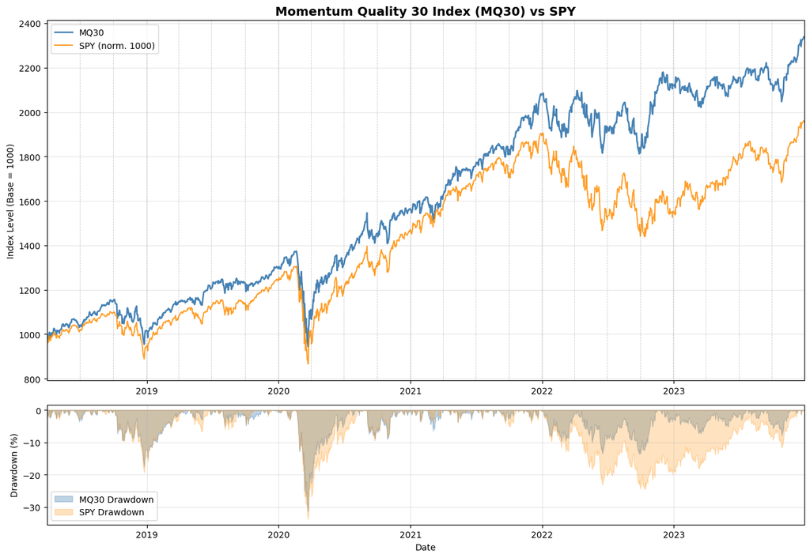

```
Chart saved to mq30_vs_spy.png
```

```python
#  Performance Chart
print('STEP 6: Performance Chart')

spy_available = False
try:
    spy_raw = yf.download('SPY', start=START_DATE, end=END_DATE,
                          auto_adjust=True, progress=False)['Close'].squeeze()
    spy_raw.index = pd.to_datetime(spy_raw.index)
    spy_norm      = (spy_raw / spy_raw.iloc[0]) * BASE_LEVEL
    aligned_spy   = spy_norm.reindex(index_levels.index, method='ffill')
    spy_available = True
    print('SPY downloaded.')
except Exception as e:
    print(f'SPY download failed ({e}); plotting MQ30 only.')

fig, (ax1, ax2) = plt.subplots(2, 1, figsize=(13, 9),
                                gridspec_kw={'height_ratios': [3, 1]})

ax1.plot(index_levels.index, index_levels.values,
         label='MQ30', lw=1.8, color='steelblue')
if spy_available:
    ax1.plot(aligned_spy.index, aligned_spy.values,
             label='SPY (norm. 1000)', lw=1.4, color='darkorange', alpha=0.85)
for d in rebalance_log.index:
    ax1.axvline(d, color='grey', lw=0.6, ls='--', alpha=0.4)
ax1.set_title('Momentum Quality 30 Index (MQ30) vs SPY',
              fontsize=14, fontweight='bold')
ax1.set_ylabel('Index Level (Base = 1000)')
ax1.legend(); ax1.grid(alpha=0.3)
ax1.xaxis.set_major_formatter(mdates.DateFormatter('%Y'))
ax1.set_xlim(index_levels.index[0], index_levels.index[-1])

dd = (index_levels / index_levels.cummax() - 1) * 100
ax2.fill_between(dd.index, dd.values, 0,
                 color='steelblue', alpha=0.35, label='MQ30 Drawdown')
if spy_available:
    spy_dd = (aligned_spy / aligned_spy.cummax() - 1) * 100
    ax2.fill_between(spy_dd.index, spy_dd.values, 0,
                     color='darkorange', alpha=0.25, label='SPY Drawdown')
ax2.set_ylabel('Drawdown (%)'); ax2.set_xlabel('Date')
ax2.legend(); ax2.grid(alpha=0.3)
ax2.xaxis.set_major_formatter(mdates.DateFormatter('%Y'))
ax2.set_xlim(index_levels.index[0], index_levels.index[-1])

plt.tight_layout()
plt.savefig(os.path.join(OUTPUT_DIR, 'mq30_vs_spy.png'), dpi=150, bbox_inches='tight')
plt.show()
print('Chart saved to mq30_vs_spy.png')
```

```python
#  Summary Statistics
print('STEP 7: Summary Statistics')

def ann_ret(s):         return (s.iloc[-1] / s.iloc[0]) ** (252 / len(s)) - 1
def ann_vol(s):         return s.pct_change().dropna().std() * np.sqrt(252)
def sharpe(s, rf=0.04): return (ann_ret(s) - rf) / ann_vol(s)
def mdd(s):             return ((s / s.cummax()) - 1).min()
def calmar(s):          return ann_ret(s) / abs(mdd(s))

print('\nMQ30:')
for label, val in [
    ('Ann. Return',      f'{ann_ret(index_levels):.2%}'),
    ('Ann. Volatility',  f'{ann_vol(index_levels):.2%}'),
    ('Sharpe (rf=4%)',   f'{sharpe(index_levels):.2f}'),
    ('Max Drawdown',     f'{mdd(index_levels):.2%}'),
    ('Calmar Ratio',     f'{calmar(index_levels):.2f}'),
    ('Total Return',     f'{index_levels.iloc[-1] / index_levels.iloc[0] - 1:.2%}'),
]:
    print(f'  {label:<22} {val}')

if spy_available:
    spy_c = aligned_spy.dropna()
    print('\nSPY: ')
    for label, val in [
        ('Ann. Return',      f'{ann_ret(spy_c):.2%}'),
        ('Ann. Volatility',  f'{ann_vol(spy_c):.2%}'),
        ('Sharpe (rf=4%)',   f'{sharpe(spy_c):.2f}'),
        ('Max Drawdown',     f'{mdd(spy_c):.2%}'),
        ('Calmar Ratio',     f'{calmar(spy_c):.2f}'),
        ('Total Return',     f'{spy_c.iloc[-1] / spy_c.iloc[0] - 1:.2%}'),
    ]:
        print(f'  {label:<22} {val}')

print('\nLast Rebalance Top 10 by Weight:')
if len(constituent_history):
    last_reb = constituent_history['date'].max()
    snap = (
        constituent_history[constituent_history['date'] == last_reb]
        .sort_values('weight', ascending=False)
        .head(10)[['ticker', 'weight', 'momentum', 'volatility']]
        .copy()
    )
    snap['weight']     = snap['weight'].map('{:.2%}'.format)
    snap['momentum']   = snap['momentum'].map('{:.2%}'.format)
    snap['volatility'] = snap['volatility'].map('{:.2%}'.format)
    print(snap.to_string(index=False))
```

```
STEP 7: Summary Statistics

MQ30:
  Ann. Return            15.93%
  Ann. Volatility        19.06%
  Sharpe (rf=4%)         0.63
  Max Drawdown           -31.35%
  Calmar Ratio           0.51
  Total Return           133.95%

SPY:
  Ann. Return            12.71%
  Ann. Volatility        20.40%
  Sharpe (rf=4%)         0.43
  Max Drawdown           -33.72%
  Calmar Ratio           0.38
  Total Return           98.92%

Last Rebalance Top 10 by Weight:
ticker weight momentum volatility
 BRK-B  5.61%   18.21%     11.55%
     V  4.85%   25.01%     13.35%
   MCD  4.62%    7.51%     14.04%
   JPM  4.38%   19.98%     14.79%
   UNH  4.38%    2.41%     14.81%
   IBM  4.21%   17.25%     15.40%
  AAPL  4.16%   51.09%     15.56%
   ACN  4.02%   28.70%     16.13%
    PG  3.95%    1.98%     16.40%
    MA  3.59%   20.58%     18.05%
```